# ElectricCars

## Initial Imports

```python
import pandas as pd
import matplotlib.pyplot as plt
import seaborn as sns
sns.set_style("whitegrid")
```

```python
data=pd.read_csv('C:/Users/alrod/Documents/ProyectoCoches/Electric_Vehicle_Population_Data.csv')
# Data obtained from https://amanxai.com/2024/03/18/electric-vehicles-market-size-analysis-using-python/#google_vignette
```

```python
data.head(3)
```

|  | VIN (1-10) | County | City | State | Postal Code | Model Year | Make | Model | Electric Vehicle Type | Clean Alternative Fuel Vehicle (CAFV) Eligibility | Electric Range | Base MSRP | Legislative District | DOL Vehicle ID | Vehicle Location | Electric Utility | 2020 Census Tract |
| --- | --- | --- | --- | --- | --- | --- | --- | --- | --- | --- | --- | --- | --- | --- | --- | --- | --- |
| 0 | 5YJYGDEE1L | King | Seattle | WA | 98122.0 | 2020 | TESLA | MODEL Y | Battery Electric Vehicle (BEV) | Clean Alternative Fuel Vehicle Eligible | 291 | 0 | 37.0 | 125701579 | POINT (-122.30839 47.610365) | CITY OF SEATTLE - (WA)\|CITY OF TACOMA - (WA) | 5.303301e+10 |
| 1 | 7SAYGDEE9P | Snohomish | Bothell | WA | 98021.0 | 2023 | TESLA | MODEL Y | Battery Electric Vehicle (BEV) | Eligibility unknown as battery range has not b... | 0 | 0 | 1.0 | 244285107 | POINT (-122.179458 47.802589) | PUGET SOUND ENERGY INC | 5.306105e+10 |
| 2 | 5YJSA1E4XK | King | Seattle | WA | 98109.0 | 2019 | TESLA | MODEL S | Battery Electric Vehicle (BEV) | Clean Alternative Fuel Vehicle Eligible | 270 | 0 | 36.0 | 156773144 | POINT (-122.34848 47.632405) | CITY OF SEATTLE - (WA)\|CITY OF TACOMA - (WA) | 5.303301e+10 |

```python
data.info()
```

```
<class 'pandas.core.frame.DataFrame'>
RangeIndex: 177866 entries, 0 to 177865
Data columns (total 17 columns):
 #   Column                                             Non-Null Count   Dtype
---  ------                                             --------------   -----
 0   VIN (1-10)                                         177866 non-null  object
 1   County                                             177861 non-null  object
 2   City                                               177861 non-null  object
 3   State                                              177866 non-null  object
 4   Postal Code                                        177861 non-null  float64
 5   Model Year                                         177866 non-null  int64
 6   Make                                               177866 non-null  object
 7   Model                                              177866 non-null  object
 8   Electric Vehicle Type                              177866 non-null  object
 9   Clean Alternative Fuel Vehicle (CAFV) Eligibility  177866 non-null  object
 10  Electric Range                                     177866 non-null  int64
 11  Base MSRP                                          177866 non-null  int64
 12  Legislative District                               177477 non-null  float64
 13  DOL Vehicle ID                                     177866 non-null  int64
 14  Vehicle Location                                   177857 non-null  object
 15  Electric Utility                                   177861 non-null  object
 16  2020 Census Tract                                  177861 non-null  float64
dtypes: float64(3), int64(4), object(10)
memory usage: 23.1+ MB
```

## Data Cleaning

```python
data.isnull().sum()
```

```
VIN (1-10)                                             0
County                                                 5
City                                                   5
State                                                  0
Postal Code                                            5
Model Year                                             0
Make                                                   0
Model                                                  0
Electric Vehicle Type                                  0
Clean Alternative Fuel Vehicle (CAFV) Eligibility      0
Electric Range                                         0
Base MSRP                                              0
Legislative District                                 389
DOL Vehicle ID                                         0
Vehicle Location                                       9
Electric Utility                                       5
2020 Census Tract                                      5
dtype: int64
```

```python
data=data.dropna()
```

```python
data.isnull().sum()
```

```
VIN (1-10)                                           0
County                                               0
City                                                 0
State                                                0
Postal Code                                          0
Model Year                                           0
Make                                                 0
Model                                                0
Electric Vehicle Type                                0
Clean Alternative Fuel Vehicle (CAFV) Eligibility    0
Electric Range                                       0
Base MSRP                                            0
Legislative District                                 0
DOL Vehicle ID                                       0
Vehicle Location                                     0
Electric Utility                                     0
2020 Census Tract                                    0
dtype: int64
```

#### Our working file has no blank spaces anymore!

## Year Analysis

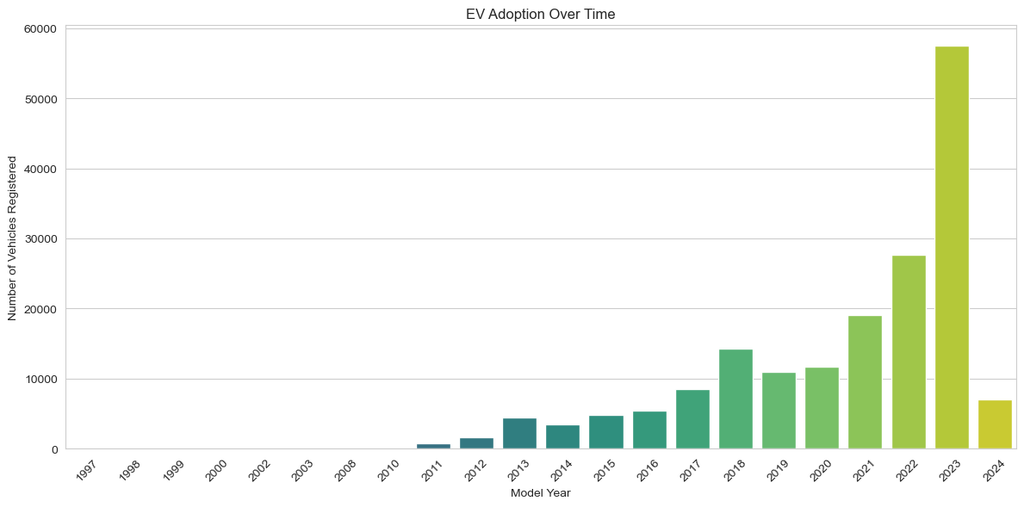

```python
plt.figure(figsize=(12, 6))
ev_adoption_by_year = data['Model Year'].value_counts().sort_index()
sns.barplot(x=ev_adoption_by_year.index, y=ev_adoption_by_year.values, palette="viridis")
plt.title('EV Adoption Over Time')
plt.xlabel('Model Year')
plt.ylabel('Number of Vehicles Registered')
plt.xticks(rotation=45)
plt.tight_layout()
```

#### We are strudying the EV vehicles adoption in the last years. Based in the previous graph, we observe a gradual increase that has a seve4re peak in 2023. Year 2024 shows fewer units, since the data covers only a few initial months.

#### US County Study

```python
condados=data['County'].value_counts()
```

```python
condados.head()
```

```
County
King         92740
Snohomish    21001
Pierce       13782
Clark        10409
Thurston      6428
Name: count, dtype: int64
```

```python
##v Explorar esto en el ejemplo
top_counties = condados.head(3).index
print(top_counties)
```

```
Index(['King', 'Snohomish', 'Pierce'], dtype='object', name='County')
```

```python
# Filtro por condados

condados_filt=data[data['County'].isin(top_counties)]
condados_filt.head(3)
```

|  | VIN (1-10) | County | City | State | Postal Code | Model Year | Make | Model | Electric Vehicle Type | Clean Alternative Fuel Vehicle (CAFV) Eligibility | Electric Range | Base MSRP | Legislative District | DOL Vehicle ID | Vehicle Location | Electric Utility | 2020 Census Tract |
| --- | --- | --- | --- | --- | --- | --- | --- | --- | --- | --- | --- | --- | --- | --- | --- | --- | --- |
| 0 | 5YJYGDEE1L | King | Seattle | WA | 98122.0 | 2020 | TESLA | MODEL Y | Battery Electric Vehicle (BEV) | Clean Alternative Fuel Vehicle Eligible | 291 | 0 | 37.0 | 125701579 | POINT (-122.30839 47.610365) | CITY OF SEATTLE - (WA)\|CITY OF TACOMA - (WA) | 5.303301e+10 |
| 1 | 7SAYGDEE9P | Snohomish | Bothell | WA | 98021.0 | 2023 | TESLA | MODEL Y | Battery Electric Vehicle (BEV) | Eligibility unknown as battery range has not b... | 0 | 0 | 1.0 | 244285107 | POINT (-122.179458 47.802589) | PUGET SOUND ENERGY INC | 5.306105e+10 |
| 2 | 5YJSA1E4XK | King | Seattle | WA | 98109.0 | 2019 | TESLA | MODEL S | Battery Electric Vehicle (BEV) | Clean Alternative Fuel Vehicle Eligible | 270 | 0 | 36.0 | 156773144 | POINT (-122.34848 47.632405) | CITY OF SEATTLE - (WA)\|CITY OF TACOMA - (WA) | 5.303301e+10 |

```python
#distribución_Por_Condado
dist_condados=condados_filt.groupby(['County', 'City']).size().sort_values(ascending=False).reset_index(name='Number of Vehicles')
condadostop=dist_condados.head(10)
print(condadostop)
```

```
      County       City  Number of Vehicles
0       King    Seattle               29447
1       King   Bellevue                8930
2       King    Redmond                6478
3       King   Kirkland                5362
4       King  Sammamish                5280
5       King     Renton                4980
6  Snohomish    Bothell                4663
7     Pierce     Tacoma                3722
8       King    Tukwila                2927
9       King       Kent                2782
```

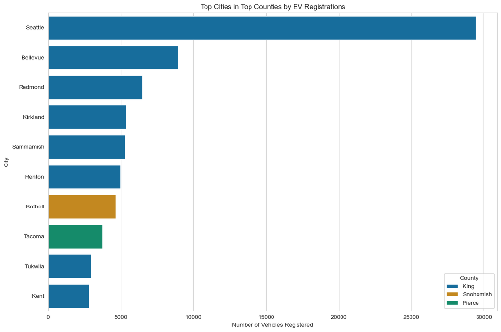

```python
plt.figure(figsize=(12, 8))
sns.barplot(x='Number of Vehicles', y='City', hue='County', data=condadostop, palette="colorblind")
plt.title('Top Cities in Top Counties by EV Registrations')
plt.xlabel('Number of Vehicles Registered')
plt.ylabel('City')
plt.legend(title='County')
plt.tight_layout()
plt.show()
```

#### From the plot above, we can conclude the following:

- Cities located in the King county are the most populous in terms of EV vehicles, led by Seattle.
- Cities located in the two remaining counties, Pierce and Snomish ahow a remarcabilly lower EV vehicle addoption.
- Even so, the cities with the lowest numbers are also in King county.

## Types based Distribution

```python
typesdist=data['Electric Vehicle Type'].value_counts()
typesdist.head()
```

```
Electric Vehicle Type
Battery Electric Vehicle (BEV)            138947
Plug-in Hybrid Electric Vehicle (PHEV)     38526
Name: count, dtype: int64
```

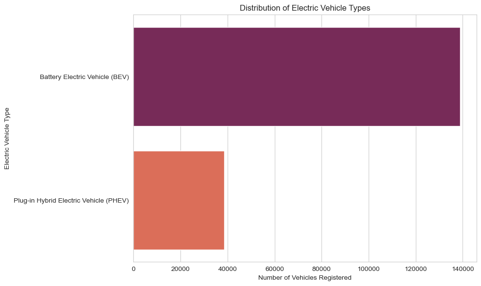

```python
plt.figure(figsize=(10, 6))
sns.barplot(x=typesdist.values, y=typesdist.index, palette="rocket")
plt.title('Distribution of Electric Vehicle Types')
plt.xlabel('Number of Vehicles Registered')
plt.ylabel('Electric Vehicle Type')
plt.tight_layout()
plt.show()
```

#### From this last plot, we van conclude, as expected, that the BEV is much more popular than the PHEV.

## Make's Popularity

```python
mostpop=data['Make'].value_counts().head(10)
mostpop.head(10)
```

```
Make
TESLA         79471
NISSAN        13984
CHEVROLET     13651
FORD           9177
BMW            7556
KIA            7423
TOYOTA         6254
VOLKSWAGEN     4993
JEEP           4468
HYUNDAI        4398
Name: count, dtype: int64
```

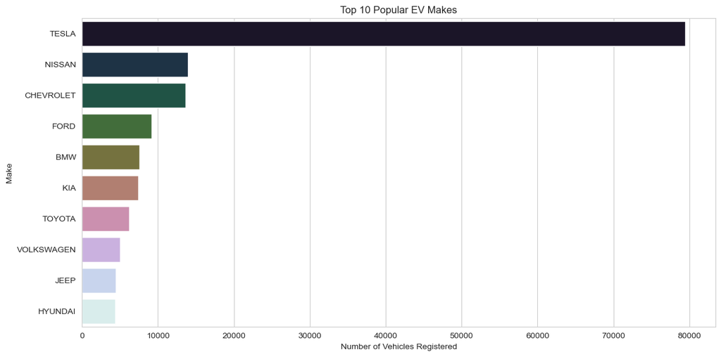

```python
plt.figure(figsize=(12, 6))
sns.barplot(x=mostpop.values, y=mostpop.index, palette="cubehelix")
plt.title('Top 10 Popular EV Makes')
plt.xlabel('Number of Vehicles Registered')
plt.ylabel('Make')
plt.tight_layout()
plt.show()
```

```python
popmakes=mostpop.head(3).index
print(popmakes)
```

```
Index(['TESLA', 'NISSAN', 'CHEVROLET'], dtype='object', name='Make')
```

```python
tops_data=data[data['Make'].isin(popmakes)]
tops_data.head(3)
```

|  | VIN (1-10) | County | City | State | Postal Code | Model Year | Make | Model | Electric Vehicle Type | Clean Alternative Fuel Vehicle (CAFV) Eligibility | Electric Range | Base MSRP | Legislative District | DOL Vehicle ID | Vehicle Location | Electric Utility | 2020 Census Tract |
| --- | --- | --- | --- | --- | --- | --- | --- | --- | --- | --- | --- | --- | --- | --- | --- | --- | --- |
| 0 | 5YJYGDEE1L | King | Seattle | WA | 98122.0 | 2020 | TESLA | MODEL Y | Battery Electric Vehicle (BEV) | Clean Alternative Fuel Vehicle Eligible | 291 | 0 | 37.0 | 125701579 | POINT (-122.30839 47.610365) | CITY OF SEATTLE - (WA)\|CITY OF TACOMA - (WA) | 5.303301e+10 |
| 1 | 7SAYGDEE9P | Snohomish | Bothell | WA | 98021.0 | 2023 | TESLA | MODEL Y | Battery Electric Vehicle (BEV) | Eligibility unknown as battery range has not b... | 0 | 0 | 1.0 | 244285107 | POINT (-122.179458 47.802589) | PUGET SOUND ENERGY INC | 5.306105e+10 |
| 2 | 5YJSA1E4XK | King | Seattle | WA | 98109.0 | 2019 | TESLA | MODEL S | Battery Electric Vehicle (BEV) | Clean Alternative Fuel Vehicle Eligible | 270 | 0 | 36.0 | 156773144 | POINT (-122.34848 47.632405) | CITY OF SEATTLE - (WA)\|CITY OF TACOMA - (WA) | 5.303301e+10 |

```python
modelmake=tops_data.groupby(['Make','Model']).size().sort_values(ascending=False).reset_index(name='Number of Vehicles')
topmodelmake=modelmake.head(10)
```

```python
topmodelmake.head()
```

|  | Make | Model | Number of Vehicles |
| --- | --- | --- | --- |
| 0 | TESLA | MODEL Y | 35921 |
| 1 | TESLA | MODEL 3 | 30009 |
| 2 | NISSAN | LEAF | 13352 |
| 3 | TESLA | MODEL S | 7711 |
| 4 | CHEVROLET | BOLT EV | 6811 |

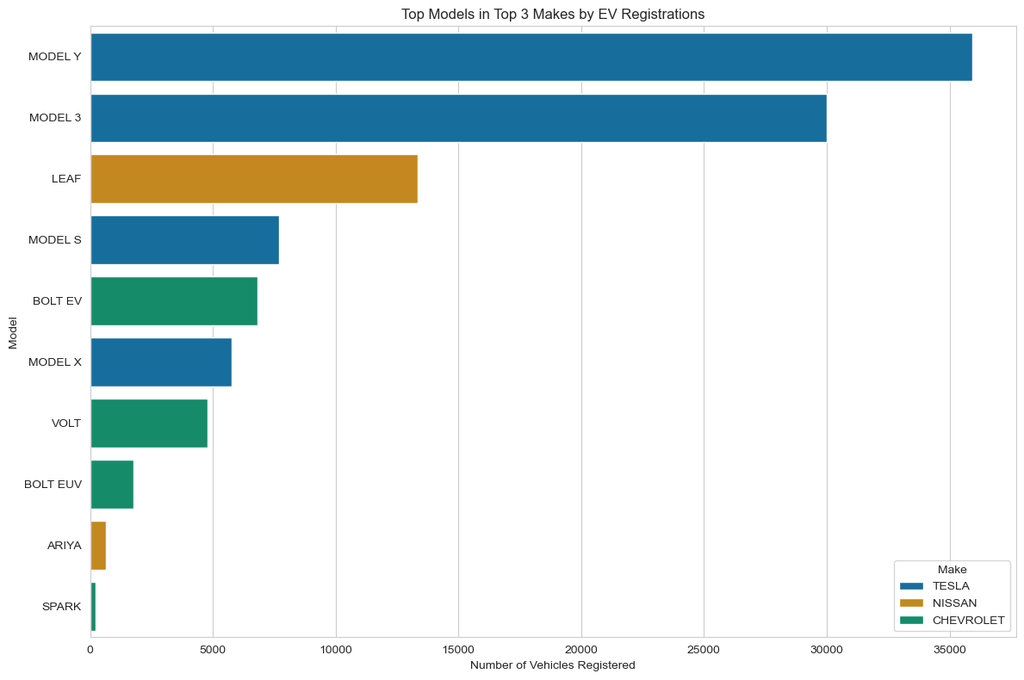

```python
plt.figure(figsize=(12, 8))
sns.barplot(x='Number of Vehicles', y='Model', hue='Make', data=topmodelmake, palette="colorblind")
plt.title('Top Models in Top 3 Makes by EV Registrations')
plt.xlabel('Number of Vehicles Registered')
plt.ylabel('Model')
plt.legend(title='Make')
plt.tight_layout()
plt.show()
```

#### Again, Tesla is shown as the lead make, with their Model Y as lead vehicle

### We will then study the vehicles' range

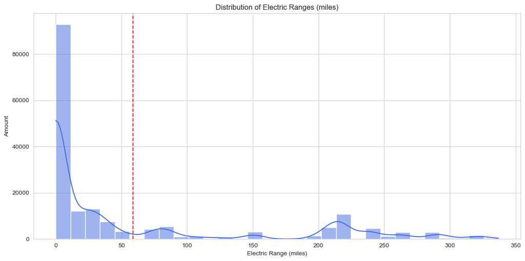

```python
plt.figure(figsize=(12, 6))
sns.histplot(data['Electric Range'], bins=30, kde=True, color='royalblue')
plt.axvline(data['Electric Range'].mean(), color='red', linestyle='--', label=f'Mean Range: {data["Electric Range"].mean():.2f} miles')
plt.title('Distribution of Electric Ranges (miles)')
plt.xlabel('Electric Range (miles)')
plt.ylabel('Amount')
plt.tight_layout()
plt.show()
```

```python
RangeMean=data['Electric Range'].mean()

print('Range mean: ',RangeMean)
```

```
Range mean:  58.82654826367955
```

## Range increase Through the Years

```python
range_by_years=data.groupby('Model Year')['Electric Range'].mean().reset_index()
```

```python
print(range_by_years)
```

```
    Model Year  Electric Range
0         1997       39.000000
1         1998       58.000000
2         1999       74.000000
3         2000       58.000000
4         2002       95.000000
5         2003       95.000000
6         2008      220.000000
7         2010      226.086957
8         2011       70.891613
9         2012       61.172243
10        2013       79.822232
11        2014       80.798341
12        2015       98.254869
13        2016      101.197111
14        2017      114.162292
15        2018      156.165967
16        2019      176.918904
17        2020      238.748978
18        2021       11.402665
19        2022        4.518045
20        2023        3.729168
21        2024       16.791431
```

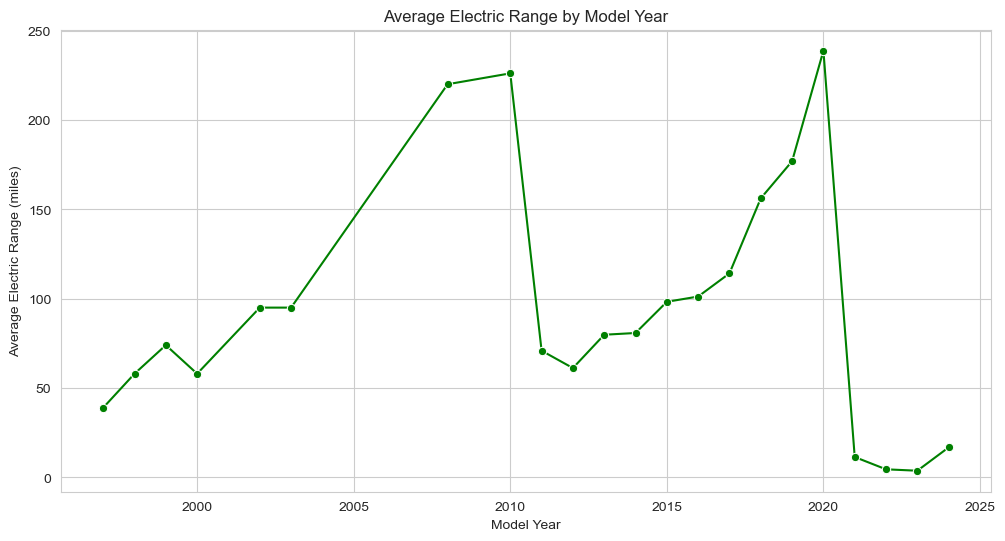

```python
plt.figure(figsize=(12, 6))
sns.lineplot(x='Model Year', y='Electric Range', data=range_by_years, marker='o', color='green')
plt.title('Average Electric Range by Model Year')
plt.xlabel('Model Year')
plt.ylabel('Average Electric Range (miles)')
plt.grid(True)
plt.show()
```

There ar two years, 2010 and 2020m at which the average battery range declined, however the last points in the graph seem to indicate a revcovery trend.